# Anatomy of a modular toolchain for reproducible bioinformatics workflows

Kelly Sovacool, PhD

Bioinformatics Software Engineer

CCR Collaborative Bioinformatics Resource

May 14, 2026

## Reproducible Bioinformatics

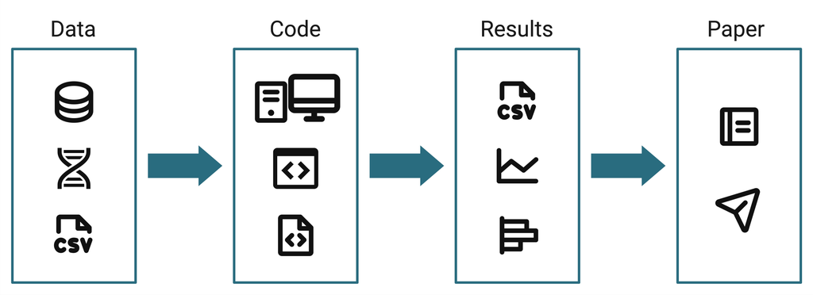

## Reproducible Bioinformatics

- **Reproducibilty** is the ability to repeat an analysis with the same methods on the **same data** and get the same result
- **Replicability** is the ability to repeat an analysis with the same methods on **different data** and get the same result

| Methods | Same data | Different data |
| --- | --- | --- |
| Same methods | Reproducibility | Replicability |
| Different methods | Robustness | Generalizability |

Schloss PD. 2018. 10.1128/mBio.00525-18.

## Enabling Reproducibility

In order for a computational biology study to be reproducible, other people must be able to run the analysis code themselves.

[figure not shown]

## Enabling Reproducibility: Bare Minimum

- Share the code publicly
- Document how to run the code

## Minimal Reproducibility

- Share the code publicly
- Document how to run the code

### Beyond Minimal Reproducibility

#### Scalability, Reusability, & Sustainability

- Ensure the code **scales** for large datasets
- **Reuse** components of your code, and ensure others can reuse it too
- Adopt maintenance practices to **sustain** the project for the long term

## CCBR Pipelines

#### On the Biowulf HPC

`$ module load ccbrpipeliner`

```
PIPELINES:
ASPEN       v1.1    ATAC-seq            https://ccbr.github.io/ASPEN/1.1
CARLISLE    v2.7    CUT&RUN             https://ccbr.github.io/CARLISLE/2.7
CHAMPAGNE   v0.5    ChIP-seq            https://ccbr.github.io/CHAMPAGNE/0.5
CHARLIE     v0.12   circRNAs            https://ccbr.github.io/CHARLIE/0.12
CRISPIN     v1.2    CRISPR              https://ccbr.github.io/CRISPIN/1.2
ESCAPE      v1.2    EV-seq              https://ccbr.github.io/ESCAPE/1.2
LOGAN       v0.3    whole genome seq    https://ccbr.github.io/LOGAN/0.3
RENEE       v2.7    bulk RNA-seq        https://ccbr.github.io/RENEE/2.7
SINCLAIR    v0.3    scRNA-seq           https://ccbr.github.io/SINCLAIR/0.3
XAVIER      v3.2    whole exome-seq     https://ccbr.github.io/XAVIER/3.2

TOOLS:
spacesavers2    v0.14           https://ccbr.github.io/spacesavers2/
permfix         v0.6            https://github.com/ccbr/permfix/
ccbr_tools      v0.4            https://ccbr.github.io/Tools/
```

## How can we develop bioinformatics workflows that are scalable, reusable, and sustainable to maximize reproducibility?

## Toolchain for Reproducible Bioinformatics

[figure not shown]

## The Bioinformatics workflow

Example workflow diagram from CHAMPAGNE: ChIP-seq pipeline

[figure not shown]

https://github.com/CCBR/CHAMPAGNE

## The Bioinformatics workflow

### Nextflow for scalable orchestration

[figure not shown]

https://carpentries-incubator.github.io/workflows-nextflow/01-getting-started-with-nextflow.html

## Workflow template for new pipelines

[figure not shown]

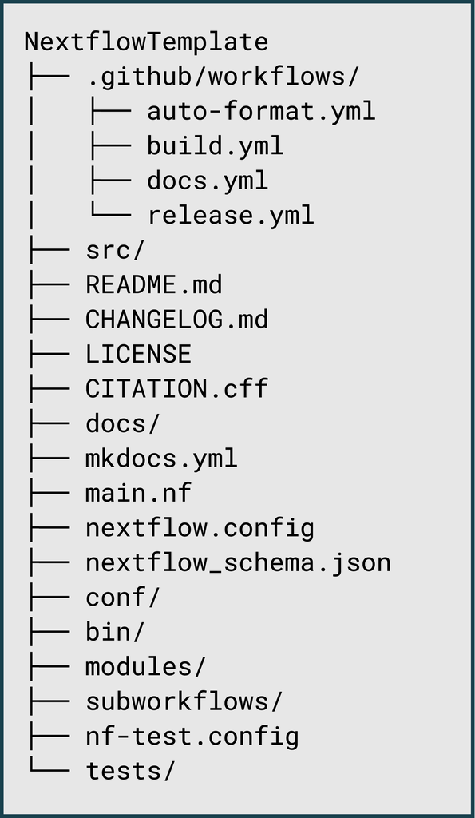

https://github.com/CCBR/CCBR_NextflowTemplate

## Workflow template for new pipelines

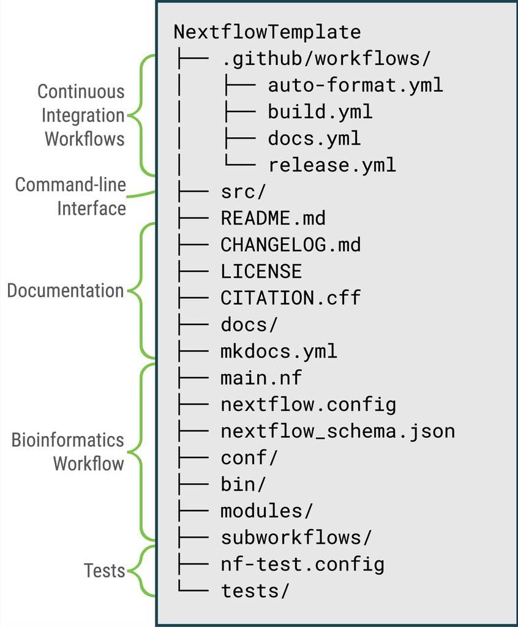

https://github.com/CCBR/CCBR_NextflowTemplate

## The Command-line Interface

Nextflow native interface

```bash
nextflow run ./path/to/CCBR/CHAMPAGNE \
  -profile biowulf,slurm,singularity \
  --input /data/$USER/chipseq-project/data/samplesheet.csv
  -resume
```

CCBR custom interface

```bash
champagne run \
  --input /data/$USER/chipseq-project/data/samplesheet.csv
```

Same interface, different pipeline

```bash
sinclair run \
  --input /data/$USER/scrna-project/data/samplesheet.csv
```

## The Command-line interface

[figure not shown]

## Python Package

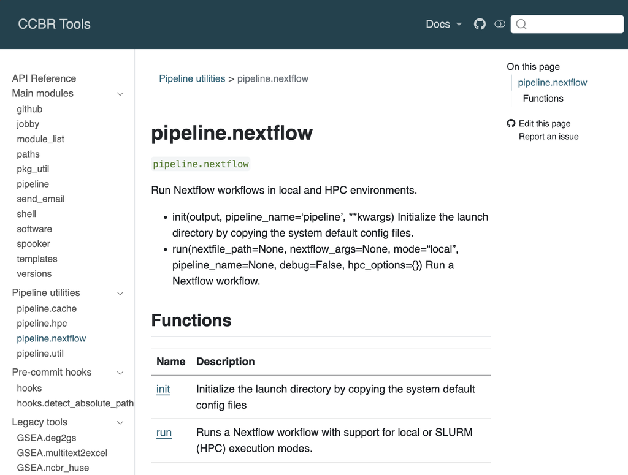

https://github.com/CCBR/Tools/

## Nextflow modules & subworkflows

Modular design enables code re-use

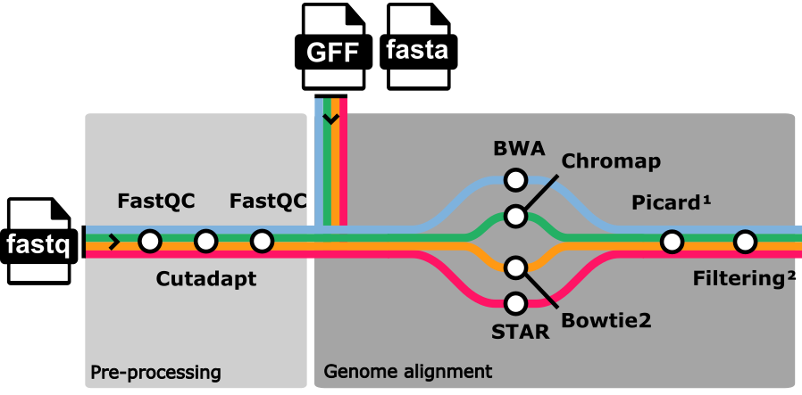

[figure not shown]

left: https://nf-co.re/chipseq/2.1.0/ | right: https://github.com/CCBR/nf-modules

## Docker containers

Dependency management: solved

[figure not shown]

## Contribution Process

Sustainable development practices for high-quality code

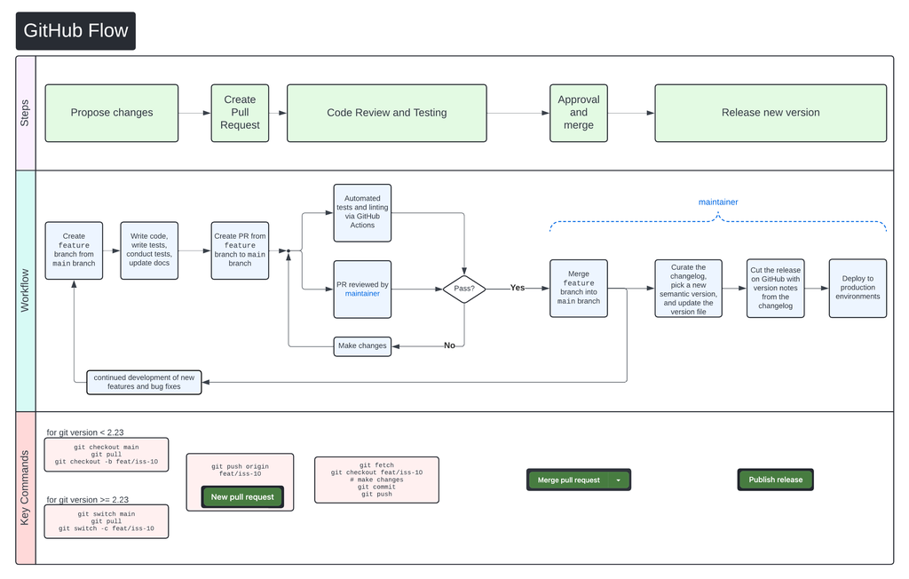

## Contribution Process: Pull Requests

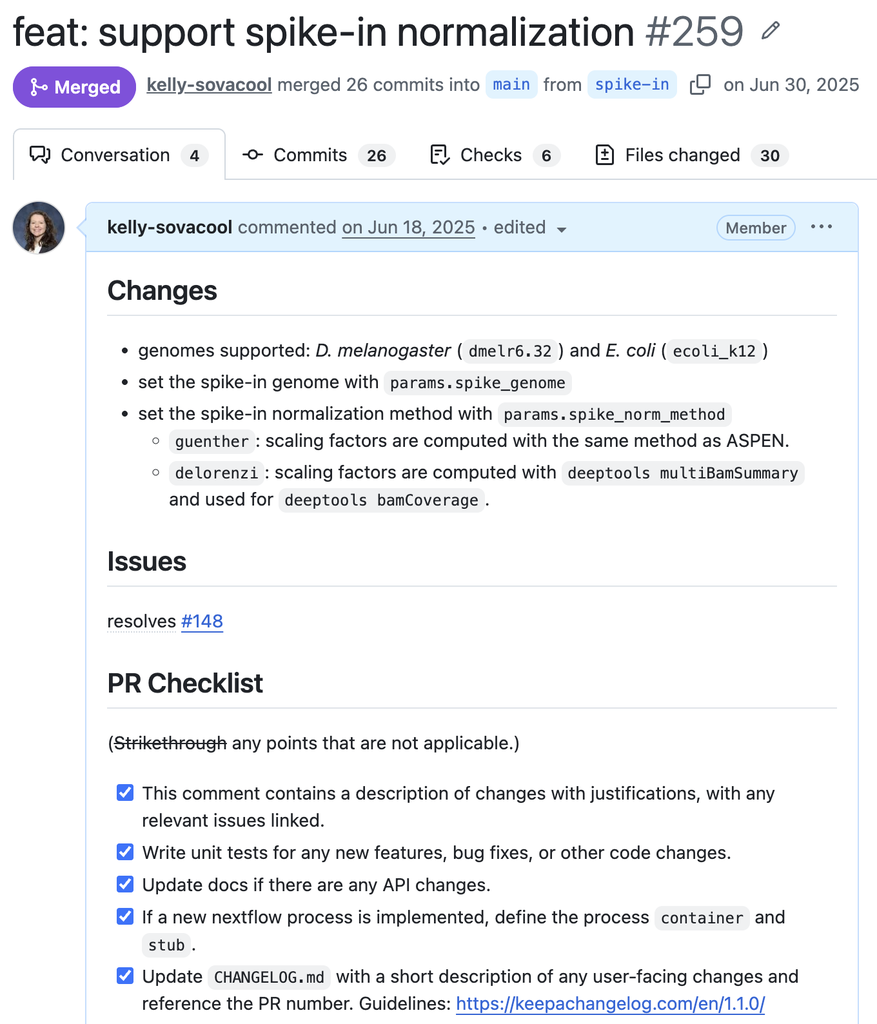

## Contribution Process

### Code review checklist

- The code is clear, concise, readable, and follows best practices.
- Unit tests demonstrate that the code works.
- If the code changes how the software behaves for users, the documentation is also updated.
- All of the continuous integration (CI) checks pass.

[figure not shown]

## Continuous Integration

- Integrate source code changes frequently
- Ensure the main branch is always in a working state

### GitHub Actions runs CI checks on every change

- Unit & integration tests, code coverage report
- Code quality checks
- Render documentation

[figure not shown]

## Deploy Documentation with GitHub Pages

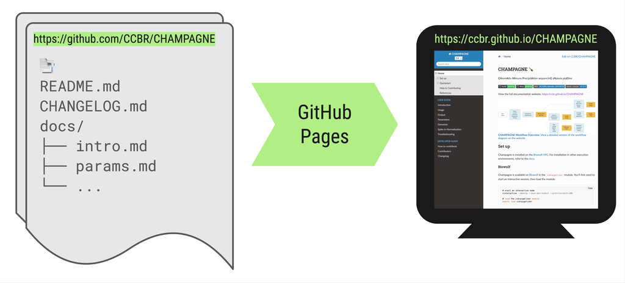

## Continuous Integration

### Reusable GitHub Actions

[figure not shown]

https://github.com/CCBR/actions

## Anatomy of our workflow template

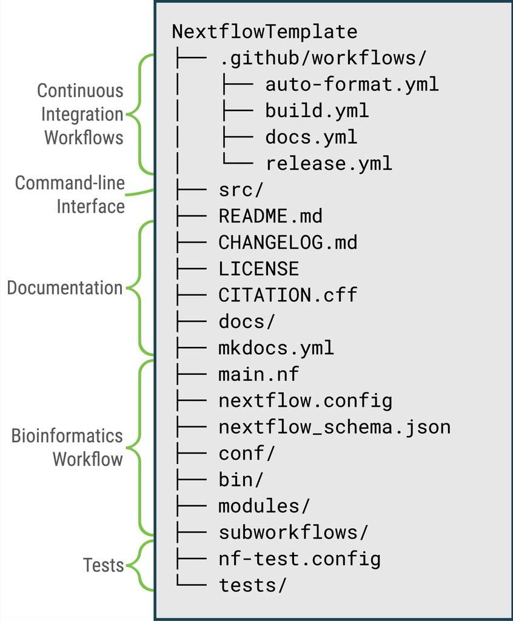

## Anatomy of our workflow template

[figure not shown]

## Scalable, Reusable, Sustainable, Reproducible Bioinformatics

[figure not shown]

## Scalable, Reusable, Sustainable, Reproducible Bioinformatics

[figure not shown]

## Resources

- These slides: [[HTML](https://ccbr.github.io/reproducible-toolchain/slides/abcs-tech-workshop-2026-05.html#/title-slide)] [[Source](https://github.com/CCBR/reproducible-toolchain/blob/main/slides/abcs-tech-workshop-2026-05.qmd)]
- Related talk: [Organizing and documenting NGS pipelines on GitHub](https://bioinfo-abcc.ncifcrf.gov/training/event/organizing-and-documenting-ngs-pipelines-on-github-building-549-executive-board-room-nci-frederick-1204241200) | ABCS Programmer’s Corner, 2024
- [CCBR Nextflow Template](https://github.com/CCBR/CCBR_NextflowTemplate)

## Discussion

- What barriers to reproducibility do you face in your development & analysis projects?
- How can you reduce repetitive code in your own projects?
- Would your team benefit from developing your own reusable packages and template repositories?
- Are you taking advantage of GitHub’s features like Actions and Pages?
- Is your contribution process helping maintain code quality?
- Are there any tools or processes you would add to this stack?